# Hackaton

PODOLAK Yan, ATALLAH Louis

2020-12-16 19:41:16

We first import the two files : the data and the test set to predict

```r
data_train = read.csv("data.csv")
test =  read.csv("test.csv")
```

We analyse the structure of the dataset to understand it better and to see the missing feature (the target) and how it’s represented : here with a 0 and 1.

```r
str(data_train)
```

```
## 'data.frame':    1817 obs. of  16 variables:
##  $ acousticness    : num  0.0102 0.199 0.0344 0.604 0.18 0.00479 0.0145 0.0202 0.0481 0.0572 ...
##  $ danceability    : num  0.833 0.743 0.838 0.494 0.678 0.804 0.739 0.266 0.603 0.525 ...
##  $ duration_ms     : num  204600 326933 185707 199413 392893 ...
##  $ energy          : num  0.434 0.359 0.412 0.338 0.561 0.56 0.472 0.348 0.944 0.855 ...
##  $ instrumentalness: num  2.19e-02 6.11e-03 2.34e-04 5.10e-01 5.12e-01 0.00 7.27e-06 6.64e-01 0.00 1.43e-02 ...
##  $ key             : int  2 1 2 5 5 8 1 10 11 5 ...
##  $ liveness        : num  0.165 0.137 0.159 0.0922 0.439 0.164 0.207 0.16 0.342 0.649 ...
##  $ loudness        : num  -8.79 -10.4 -7.15 -15.24 -11.65 ...
##  $ mode            : int  1 1 1 1 0 1 1 0 0 0 ...
##  $ speechiness     : num  0.431 0.0794 0.289 0.0261 0.0694 0.185 0.156 0.0371 0.347 0.0548 ...
##  $ tempo           : num  150.1 160.1 75 86.5 174 ...
##  $ time_signature  : int  4 4 4 4 4 4 4 4 4 3 ...
##  $ valence         : num  0.286 0.588 0.173 0.23 0.904 0.264 0.308 0.393 0.398 0.524 ...
##  $ target          : int  1 1 1 1 1 1 1 1 1 1 ...
##  $ song_title      : Factor w/ 1765 levels "'Till I Collapse",..: 946 1211 1732 947 1131 1339 297 608 715 1407 ...
##  $ artist          : Factor w/ 1253 levels "!!!","*NSYNC",..: 434 214 434 96 599 348 348 826 302 1055 ...
```

```r
head(data_train)
```

```
##   acousticness danceability duration_ms energy instrumentalness key liveness
## 1      0.01020        0.833      204600  0.434         0.021900   2   0.1650
## 2      0.19900        0.743      326933  0.359         0.006110   1   0.1370
## 3      0.03440        0.838      185707  0.412         0.000234   2   0.1590
## 4      0.60400        0.494      199413  0.338         0.510000   5   0.0922
## 5      0.18000        0.678      392893  0.561         0.512000   5   0.4390
## 6      0.00479        0.804      251333  0.560         0.000000   8   0.1640
##   loudness mode speechiness   tempo time_signature valence target
## 1   -8.795    1      0.4310 150.062              4   0.286      1
## 2  -10.401    1      0.0794 160.083              4   0.588      1
## 3   -7.148    1      0.2890  75.044              4   0.173      1
## 4  -15.236    1      0.0261  86.468              4   0.230      1
## 5  -11.648    0      0.0694 174.004              4   0.904      1
## 6   -6.682    1      0.1850  85.023              4   0.264      1
##       song_title           artist
## 1       Mask Off           Future
## 2        Redbone Childish Gambino
## 3   Xanny Family           Future
## 4 Master Of None      Beach House
## 5 Parallel Lines      Junior Boys
## 6       Sneakin’            Drake
```

We implement the pca on the data (except the target) to determine the most important features

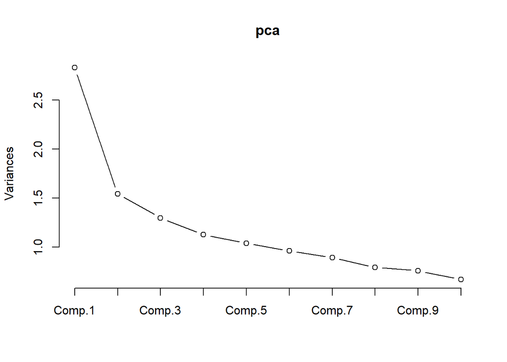

```r
data_train = data_train[,1:14]
pca = princomp(data_train[,-14], cor = T)
plot(pca, type = "l")
```

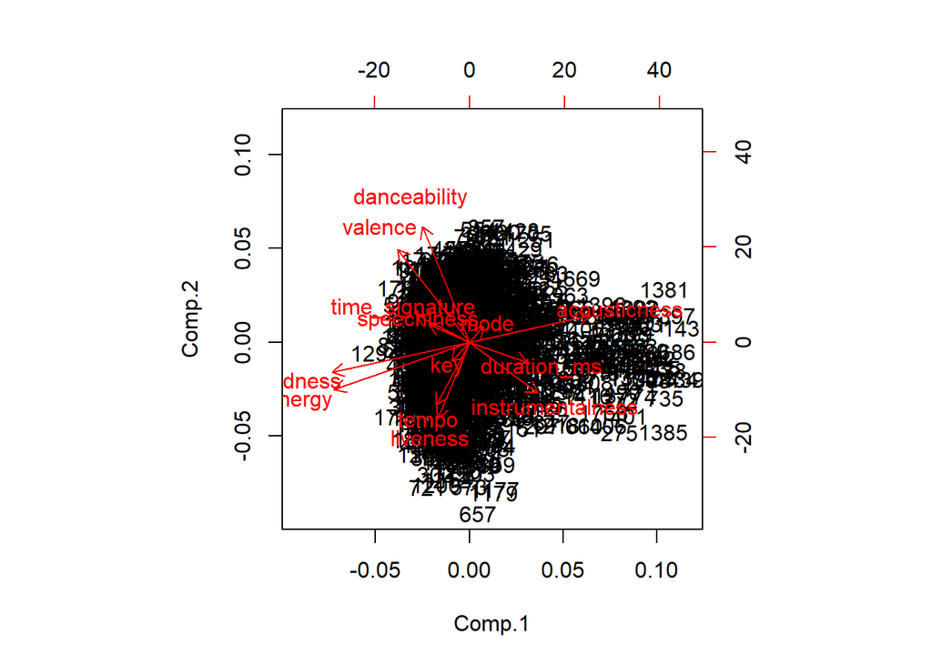

```r
biplot(pca)
```

Here, the dimension 1 is the most influent component with 21,8% and the dimension 2 with 11,9%. The 3 most important variables are loudness, energy and acousticness.

```r
library(factoextra)
```

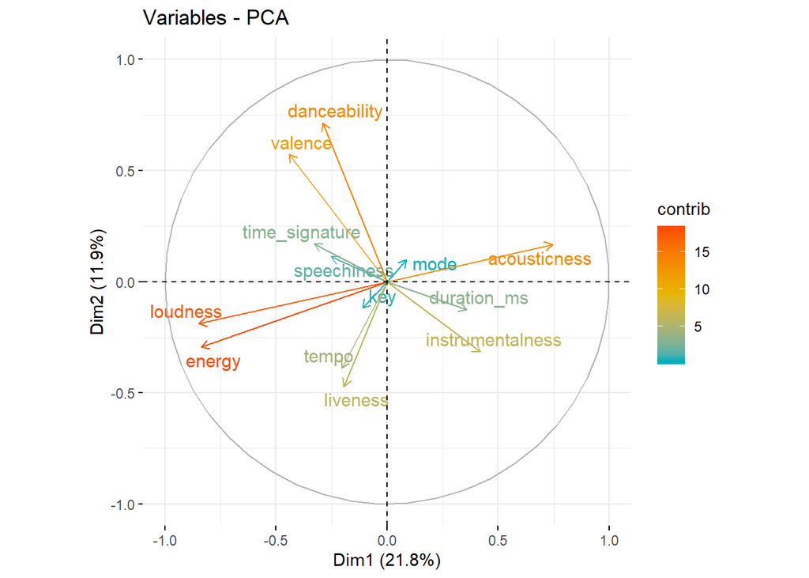

```r
fviz_pca_var(pca,
             col.var = "contrib",
             gradient.cols = c("#00AFBB", "#E7B800", "#FC4E07"),
             repel = TRUE
)
```

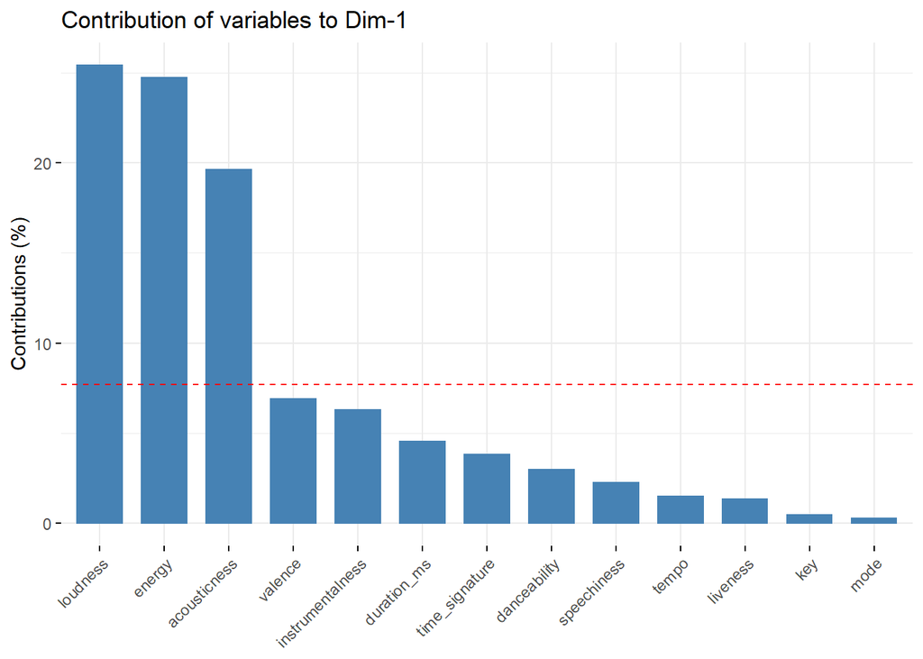

```r
fviz_contrib(pca, choice = "var", axes = 1)
```

We split the training set to train and check our model

```r
library(caTools) # install it first in the console
set.seed(703185)
split = sample.split(data_train, SplitRatio = 0.70)
training_set = subset(data_train, split == TRUE)
test_set = subset(data_train, split = FALSE)
```

We define a function about prediction accuracy to compare the target with its proper result

```r
prediction_accuracy = function(pred,actual){
  mean(pred==actual)
}
```

Here, we use the logistic regression on our 3 variables to optimize the performance

```r
model_log = glm(target~loudness+energy+acousticness, data = training_set)
summary(model_log)
```

```
##
## Call:
## glm(formula = target ~ loudness + energy + acousticness, data = training_set)
##
## Deviance Residuals:
##     Min       1Q   Median       3Q      Max
## -0.8922  -0.4912   0.1766   0.4629   0.8406
##
## Coefficients:
##               Estimate Std. Error t value Pr(>|t|)
## (Intercept)   0.150073   0.114046   1.316   0.1885
## loudness     -0.036430   0.005924  -6.150 1.06e-09 ***
## energy        0.255992   0.114598   2.234   0.0257 *
## acousticness -0.415582   0.072306  -5.748 1.16e-08 ***
## ---
## Signif. codes:  0 '***' 0.001 '**' 0.01 '*' 0.05 '.' 0.1 ' ' 1
##
## (Dispersion parameter for gaussian family taken to be 0.2379348)
##
##     Null deviance: 291.99  on 1167  degrees of freedom
## Residual deviance: 276.96  on 1164  degrees of freedom
## AIC: 1643.7
##
## Number of Fisher Scoring iterations: 2
```

```r
pred.log = predict(model_log, newdata = test_set, type = "response")
pred.log = ifelse(pred.log >=0.5,1,0)
prediction_accuracy(pred.log, test_set$target)
```

```
## [1] 0.6059439
```

```r
prediction.log = predict(model_log, newdata = test)
prediction.log = ifelse(prediction.log >=0.5,1,0)
```

We found an accuracy of 0.6059439 which is not so great.

We then use the simple tree to predict

```r
library(rpart)

model_tree = rpart(target~loudness+energy+acousticness,method = "class" ,data = training_set)
pred.tree = predict(model_tree, newdata = test_set, type= "class")
prediction_accuracy(pred.tree, test_set$target)
```

```
## [1] 0.6879472
```

```r
prediction.tree = predict(model_tree, newdata = test, type = "class")
```

We found an accuracy of 0.6879472 which is better than logistic regression but still not good enough

Then, we use the bagging. We use all the predictors to get the model because we noticed that it improved a lot our accuracy

```r
library(randomForest)
model_bagging = randomForest(target~., data = training_set, mtry = 13 , importance = TRUE, ntrees = 10000, method = "class")
pred.bagging = predict(model_bagging, newdata = test_set)
pred.bagging = ifelse(pred.bagging >=0.5,1,0)
prediction_accuracy(pred.bagging, test_set$target)
```

```
## [1] 0.9163456
```

```r
prediction.bagging = predict(model_bagging, newdata = test)
prediction.bagging = ifelse(prediction.bagging>=0.5,1,0)
```

We found an accuracy of 0.9163456 which is better than before and is a great result

We then use the random forest

```r
model_rf = randomForest(target~., data = training_set, mtry = 3, importance =TRUE, ntrees = 10000, type = "class")
pred.rf = predict(model_rf, newdata = test_set)
pred.rf = ifelse(pred.rf >=0.5,1,0)
prediction_accuracy(pred.rf, test_set$target)
```

```
## [1] 0.9185471
```

```r
prediction.rf = predict(model_rf, newdata = test)
prediction.rf = ifelse(prediction.rf >=0.5,1,0)
```

We found an accuracy of 0.9185471 which is even better, the best so far.

And then, we used the boosting model. We tried different parameters for the number of trees and the interaction depth to get the best accuracy possible.

```r
library(gbm)
model_boosting = gbm(target~., data = training_set, distribution = "bernoulli",
                     n.trees = 5000, interaction.depth = 10, shrinkage = 0.01)
pred.boosting = predict(model_boosting, newdata = test_set, type = "response")
```

```
## Using 5000 trees...
```

```r
pred.boosting = ifelse(pred.boosting>=0.5,1,0)
prediction_accuracy(pred.boosting, test_set$target)
```

```
## [1] 0.9201981
```

```r
prediction.boosting = predict(model_boosting, newdata = test)
```

```
## Using 5000 trees...
```

```r
prediction.boosting = ifelse(prediction.boosting >=0.5,1,0)
```

We found an accuracy of 0.9201981. It’s even better than the random forest.

We tried the LDA to see if we could have a better accuracy

```r
library(MASS)
model_lda = lda(target~., data = training_set)
pred.lda = predict(model_lda, newdata = test_set, type = "response")
prediction_accuracy(pred.lda$class,test_set$target)
```

```
## [1] 0.669235
```

However we obtained a lower accuracy of 0.669235.

Finally we tested the QDA

```r
model_qda = qda(target~., data = training_set)
pred.qda = predict(model_qda, newdata = test_set, type = "response")
prediction_accuracy(pred.qda$class,test_set$target)
```

```
## [1] 0.7160154
```

And we obtained also a lower accuracy of 0.7160154.

We submitted all the models except the LDA and the QDA because of their low accuracy. Our best accuracy was obtained with the boosting model.

```r
to_be_submitted = data.frame(id=rownames(test) , target=prediction.boosting)
write.csv(to_be_submitted , file = "nouveau.csv", row.names = F)
```

Here is our best prediction :

```r
prediction.boosting
```

```
##   [1] 1 1 0 0 0 1 1 1 0 0 0 0 0 0 1 0 0 1 1 0 1 1 0 0 1 1 0 0 1 1 0 1 0 1 0 0 1
##  [38] 0 0 0 0 0 1 0 1 1 0 0 1 1 1 0 0 0 0 0 1 1 0 0 1 0 1 0 0 0 1 1 1 1 1 1 1 0
##  [75] 0 1 0 1 0 0 1 1 1 0 0 0 0 0 0 0 1 1 1 1 0 1 0 1 1 1 0 1 1 0 1 0 1 0 0 1 0
## [112] 0 1 0 0 1 0 0 0 0 1 0 0 0 1 0 0 1 1 1 1 1 1 1 1 0 0 0 1 0 0 1 1 0 0 1 0 0
## [149] 1 0 1 0 1 0 0 1 1 0 0 0 0 1 0 1 1 0 1 0 1 0 1 0 1 1 1 0 0 1 0 1 1 0 0 0 0
## [186] 0 0 1 0 0 0 0 1 1 0 0 0 1 0 1
```